# Barren Plateaus with PennyLane

```python
import pennylane as qml
from pennylane import numpy as np
import matplotlib.pyplot as plt
```

```python
# Set a seed for reproducibility
np.random.seed(42)

# We will use 4 qubits
num_qubits = 4

# build the sim
dev = qml.device("lightning.qubit", wires=num_qubits)

# set the set of gates
gate_set = [qml.RX, qml.RY, qml.RZ]
```

```python
def rand_circuit(params, random_gate_sequence=None, num_qubits=None):
    """A random variational quantum circuit.

    Args:
        params (array[float]): array of parameters
        random_gate_sequence (dict): a dictionary of random gates
        num_qubits (int): the number of qubits in the circuit

    Returns:
        float: the expectation value of the target observable
    """
    for i in range(num_qubits):
        qml.RY(np.pi / 4, wires=i)

    for i in range(num_qubits):
        random_gate_sequence[i](params[i], wires=i)

    # linear entanglement
    for i in range(num_qubits - 1):
        qml.CZ(wires=[i, i + 1])

    H = np.zeros((2 ** num_qubits, 2 ** num_qubits))
    H[0, 0] = 1
    wirelist = [i for i in range(num_qubits)]
    return qml.expval(qml.Hermitian(H, wirelist))
```

```python
# set variable to store the grad values
grad_vals = []
num_samples = 200

for i in range(num_samples):

    # set a dictionary of random gates from gate_set -> RX, RY, RZ
    gate_sequence = {i: np.random.choice(gate_set) for i in range(num_qubits)}

    # build the sim with the specific circuit
    qcircuit = qml.QNode(rand_circuit, dev, interface="autograd")

    # set the object gradient gradient
    grad = qml.grad(qcircuit, argnum=0)

    # random initial parameters -> angles to sample the pure quantum states
    params = np.random.uniform(0, 2 * np.pi, size=num_qubits)

    # compute the gradient
    gradient = grad(params, random_gate_sequence=gate_sequence, num_qubits=num_qubits)

    # save the results
    grad_vals.append(gradient[-1])

print("Variance of the gradients for {} random circuits: {}".format(
    num_samples, np.var(grad_vals)
    )
)
print("Mean of the gradients for {} random circuits: {}".format(
    num_samples, np.mean(grad_vals)
    )
)
```

```
Variance of the gradients for 200 random circuits: 0.005681513693081508
Mean of the gradients for 200 random circuits: -0.0010002268976521365
```

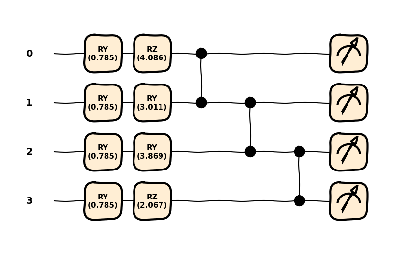

```python
fig, ax = qml.draw_mpl(rand_circuit, style="sketch", decimals=3)(params, gate_sequence, num_qubits)
```

## Plus de qubits

```
Test for 2
Test for 3
Test for 4
Test for 5
Test for 6
Test for 7
Test for 8
Test for 9
Test for 10
Test for 11
```

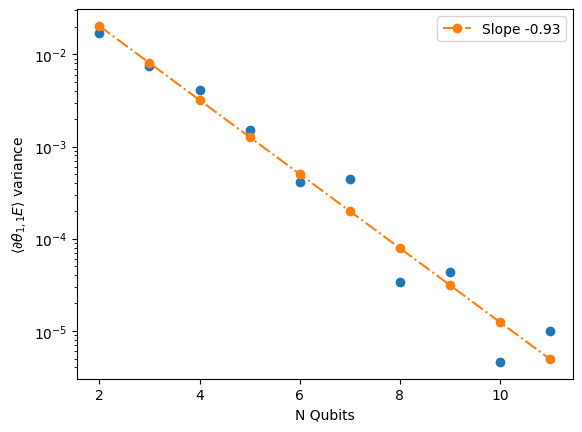

```python
# set a list of qubits
qubits = [2,3, 4, 5,6, 7,8, 9,  10, 11]

variances = []


for num_qubits in qubits:
    print(f'Test for {num_qubits}')
    grad_vals = []
    for i in range(num_samples):
        dev = qml.device("default.qubit", wires=num_qubits)
        qcircuit = qml.QNode(rand_circuit, dev, interface="autograd")
        grad = qml.grad(qcircuit, argnum=0)

        gate_set = [qml.RX, qml.RY, qml.RZ]
        random_gate_sequence = {i: np.random.choice(gate_set) for i in range(num_qubits)}

        params = np.random.uniform(0, np.pi, size=num_qubits)
        gradient = grad(
            params, random_gate_sequence=random_gate_sequence, num_qubits=num_qubits
        )
        grad_vals.append(gradient[-1])
    variances.append(np.var(grad_vals))

variances = np.array(variances)
qubits = np.array(qubits)


# Fit the semilog plot to a straight line
p = np.polyfit(qubits, np.log(variances), 1)


# Plot the straight line fit to the semilog
plt.semilogy(qubits, variances, "o")
plt.semilogy(qubits, np.exp(p[0] * qubits + p[1]), "o-.", label="Slope {:3.2f}".format(p[0]))
plt.xlabel(r"N Qubits")
plt.ylabel(r"$\langle \partial \theta_{1, 1} E\rangle$ variance")
plt.legend()
plt.show()
```

# Second tuto - Fonction de coût locale vs globale

Les [*Barren Plateaus*](https://pennylane.ai/qml/demos/tutorial_barren_plateaus/) sont de vastes régions de l'espace des paramètres de la fonction de coût où la variance du gradient est presque nulle ; en d'autres termes, le paysage de la fonction de coût est plat. Cela signifie qu'un circuit variationnel initialisé dans l'une de ces régions ne pourra pas être entraîné à l'aide d'un algorithme basé sur le gradient.

Dans "[Cost-Function-Dependent Barren Plateaus in Shallow Quantum Neural Networks](https://arxiv.org/abs/2001.00550)", Cerezo et al. démontrent l'idée que le phénomène de plateau stérile peut, dans certaines circonstances, être évité en utilisant des fonctions de coût qui ne disposent que d'informations provenant d'une partie du circuit. Ces fonctions de coût locales peuvent être plus robustes face au bruit et peuvent avoir des gradients mieux maîtrisés, sans plateau, pour les circuits peu profonds.

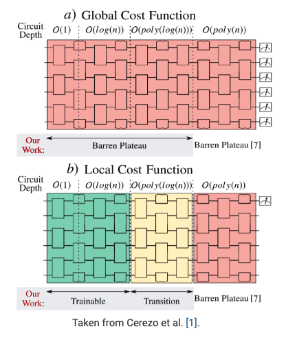

De nombreux algorithmes quantiques variationnels sont conçus pour utiliser des fonctions de coût globales. Les informations de l'ensemble de la mesure sont utilisées pour analyser le résultat du circuit, et une fonction de coût est calculée à partir de ces informations pour quantifier les performances du circuit. Une fonction de coût locale ne prend en compte que les informations de quelques qubits et tente d'analyser le comportement de l'ensemble du circuit à partir de cette portée limitée.

Cerezo et al. prouvent également que ces fonctions de coût locales sont limitées par les fonctions de coût globales, c'est-à-dire que si une fonction de coût globale est formulée de la manière décrite par Cerezo et al. la valeur de la fonction de coût locale correspondante sera toujours inférieure ou égale à la valeur de la fonction de coût globale.

Dans ce cahier, nous étudions l'effet des plateaux stériles dans les algorithmes quantiques variationnels, et comment ils peuvent être atténués en utilisant des fonctions de coût locales.

Nous devons tout d'abord importer les modules suivants.

```python
import pennylane as qml
from pennylane import numpy as np
import matplotlib.pyplot as plt
from matplotlib.ticker import LinearLocator, FormatStrFormatter

np.random.seed(42)
```